# LFMM_outliers_detection_new_var

Thomas Francisco

2024-04-30

This script will perform the candidate detection using the LFMM methods (Frichot et al. 2013). This script is based on the LFMM tutorial (Frichot and François) and the tutorial of Brenna R. Forester.

LFMM is a method that can be univariate or multivariate because we could calculate the association of SNPs with explanatory variables one by one or with all the explanatory variables together. This method can correct for population structure or not. This is a linear methods because it assumes a linear relationship between loci and climatic variables. LFMMs are regression models combining fixed (climatic variables) and latent effects (parameters influencing the association like population structure) (Caye et al. (2019)). LfMM use a framework of mixte model with latent factor, Latent factor are hidden factors that represent background residual levels of population structure.  
Latent factor are calulating using factorization methods -> that is really close to the method used in PCA -> explain why results of latent factor are close to PCs axis (Frichot et al 2013). How this work in term of models: the effect of the environmental variables (primary parameters) on the response variables is taking into account while correcting for the population structure -> the position of the individuals or population in a space just like a PCA space if I simplify it: the more the populations are close in the space the more their score will be similar and can explain the genetic variation (because the more the population are closed the more we expect them to have similar genetic compo) and more the population are far the less their score will explain the genetic variation and then other factor could explain the genetic similarities. (it’s like the example of the weigh explain by the heigh and the sex, regardless of the heigh, we found that the sex has an impact on the weigh, we study the effect of the heigh on the weigh when the sex is constant(we remove the effect of the sex on the weigh by applying is coefficient) and same things when we study the sex, we study this when the heigh is constant)

There is two types of LFMM analys: - lfmm() is Bayesian method that uses a Monte-Carlo Markov Chain algorithm - lfmm2() is a frequentist approach that uses least-squares estimates (better for large dataset 1000 to 10000 because it’s faster and also because with large dataset there is a convergence in results between frequentist and bayesian analysis).

LFMM is an analysis using allele count so we need to perform this analysis at the individual level.

We will use the multivariate LFMM analysis. There is few steps: - Load genetic and climatic data - Estimate the number of latent factor and run LFMM - Calculate the pvalues and check the pvalues distribution corrected or not by the GIF - Select the threshold(s) for candidates

```
1. Load genetic and climatic data
```

To perform LFMM, genomic data needs to be in alleles count so at the individual level and not population level. We load the genomic data at the individual level imputed (475 indiv, 8616 SNPs) with MAF correction

```r
#climatic data at individual level
load("C:/Users/tfrancisco/Documents/Thèse/Data/Espèces/Taxus_baccata/Climatic_data/new_selection/climatic_data_indivdual_level_scaled_new_selection_df.Rdata")
climatic_data <- climatic_data_indivdual_level_scaled_new_selection_df


load("C:/Users/tfrancisco/Documents/Thèse/Data/Espèces/Taxus_baccata/genetic_new/Gen_matrix_imp_T_Adapcon_Gentree_475_8616.Rdata")
#genomic data in numeric
genomic_data <- Gen_matrix_imp_T_Adapcon_Gentree_475_8616 %>% mutate_all( function(x) as.numeric(as.character(x)))


#meta_data
meta_data_pop <- read.csv("C:/Users/tfrancisco/Documents/Thèse/Data/Espèces/Taxus_baccata/Populations/taxus_sample_29pop.csv",h=T,sep=";",dec=",")
#alphabetic order
meta_data_pop_order <- meta_data_pop[order(meta_data_pop$Population),]
```

We need to adjust climatic data to the number of individuals in genomic data

```r
climatic_data_475 <- climatic_data[climatic_data$VCF_ID %in% row.names(Gen_matrix_imp_T_Adapcon_Gentree_475_8616),]
```

We can write an LFMM file or directly used genomic_data as imput of LFMM2. The input of write.geno is a dataset with individuals in rows, snps in columns and Na in 9

```r
#write.lfmm(genomic_data,"C:/Users/tfrancisco/Documents/Thèse/Data/Espèces/Taxus_baccata/genetic_new/GEA/genomic_data.lfmm")

climate_format <- climatic_data_475[,-c(1:3)]
#write.env(climate_format, "C:/Users/tfrancisco/Documents/Thèse/Data/Espèces/Taxus_baccata/genetic_new/GEA/climate_format.env")

#See if the lfmm is in the right format
visualization_writelfmm <- data.frame(read.lfmm("C:/Users/tfrancisco/Documents/Thèse/Data/Espèces/Taxus_baccata/genetic_new/GEA/genomic_data.lfmm"))
```

```
2. Estimate the number of latent factor and run LFMM
```

Based on the PC analysis with genetic data, it’s seems that the 2 first PCs axis could be enough to account for population structure because we could discriminate the 3 main genes pools identified by STRUCTURE along the 2 PCs. Latent factor is not working exactly like a PCs so we will perform the latent factor analysis to see how many latent factors are required to discriminate the 3 main genes pools.

We can perform the LFMM bayesian analysi (not used)

```r
#project = NULL
#test <- lfmm("C:/Users/tfrancisco/Documents/Thèse/Data/Espèces/Taxus_baccata/genetic_new/GEA/genomic_data.lfmm",
#             "C:/Users/tfrancisco/Documents/Thèse/Data/Espèces/Taxus_baccata/genetic_new/GEA/climate_format.env",
#             K=2,
#             repetitions=5,
#             project="new")
```

Here we decided to used the LFMM2 algorithm:

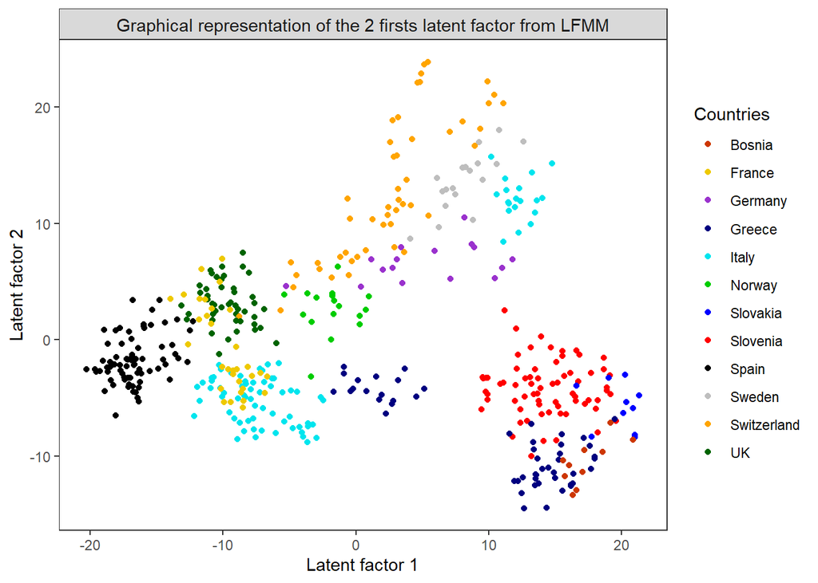

```r
Run_LFMM2 <- lfmm2(input = genomic_data, env = climatic_data_475[,-c(1:3)], K = 2, effect.sizes = T)
# GEA significance test

# showing the K = 2 estimated factors
score_LFMM <- data.frame(Run_LFMM2@U)

score_Pca <- data.frame(score_LFMM, row.names (genomic_data))
      colnames(score_Pca) <- c(paste0("PC1"), paste0("PC2"), "VCF_ID")
      #add pop info on the score_pca
  score_Pca_meta_data <- merge(climatic_data_475[,c(1:2)],score_Pca, "VCF_ID")

      # add country, population information
      PCa_df_score <- merge(score_Pca_meta_data, meta_data_pop_order, "Population")

      # genetic PCA
      latent_factor_LFMM2_candidates_selection <- ggplot() +
        geom_point(data = PCa_df_score, aes(PC1,PC2, color = Country)) +
        scale_colour_manual(name = "Countries",
                            values = c("orangered3", "gold2", "darkorchid3", "navyblue", "turquoise2", "green3", "blue", "red", "black", "gray", "orange", "darkgreen")) +
  xlab(paste0("Latent factor 1")) +
  ylab(paste0("Latent factor 2")) +
  facet_wrap(~"Graphical representation of the 2 firsts latent factor from LFMM") +
  theme_bw(base_size = 11) +
  theme(panel.grid = element_blank(), plot.background = element_blank(), panel.background = element_blank(), strip.text = element_text(size=11))

print(latent_factor_LFMM2_candidates_selection)
```

The genetic PCs and the latent factor with k=2 seems very similar. Also, “K may be replaced by estimates of population genetic structure obtained with clustering algorithms like STRUCTURE” according to Pritchard et al. 2000. Based on that and a discussion with Benjamin Dauphin (he told that we should take k= number of groups-1), With 3 main gene pool groups, we will retain k=2.

```
3. Calculate the pvalues and analyse the pvalues distribution
```

```r
#non correcting for GIF
pv_non_corrected <- lfmm2.test(object = Run_LFMM2,
input = genomic_data,
env = climatic_data_475[,-c(1:3)],
full = T,
genomic.control = F)


#correcting for GIF
pv_corrected <- lfmm2.test(object = Run_LFMM2,
input = genomic_data,
env = climatic_data_475[,-c(1:3)],
full = T,
genomic.control = T)
```

The next step is to visualize the pvalue distribution with pvalues corrected or not by the genomic inflation factor.”The genomic inflation factor expresses the deviation of the distribution of the observed test statistic compared to the distribution of the expected test statistic” Van den Berg et al. 2019 -> high GIF = indicate that we did not correct enough for population stratification etc -> high rate of false positive -> low GIF = we corrected too much and we lose a part of the signal -> high rate of false negatives -> GIF near 1 = the correction is good

To visualize which GIF seems pertinent according to our data, we can look at the shape of the distribution to visualize if we have corrected enough for the population structure because we should expect a pic of pvalues near 0 and then a continuous number of pvalues from 0.1 to 1. We can compared the distribution of corrected and not corrected for GIF.

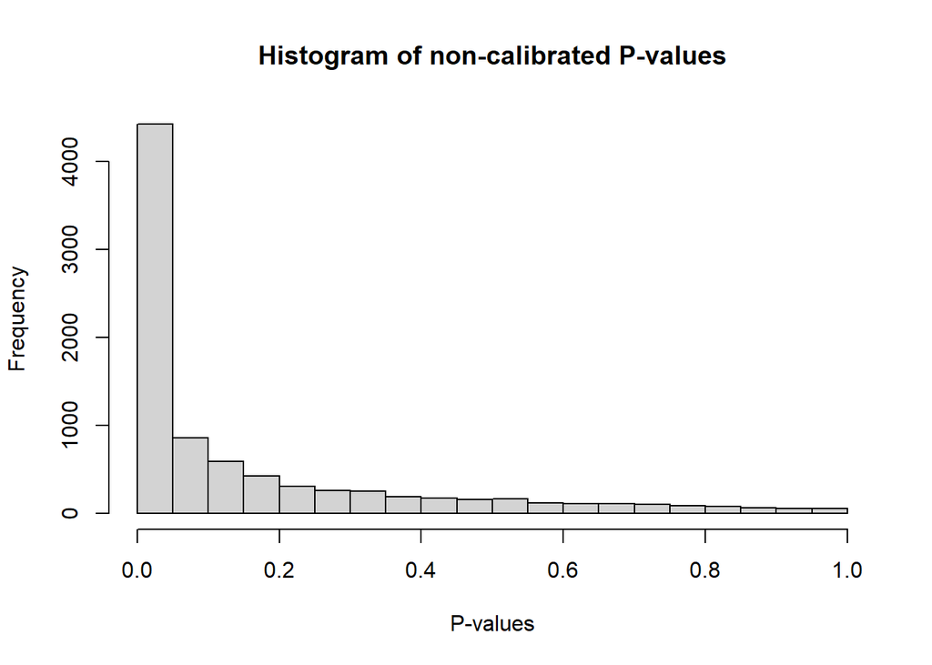

```r
#non corrected for GIF
Histogram_of_non_calibrated_Pvalues_LFMM<- hist(pv_non_corrected$pvalues,
     main= "Histogram of non-calibrated P-values",
     xlab= "P-values")
```

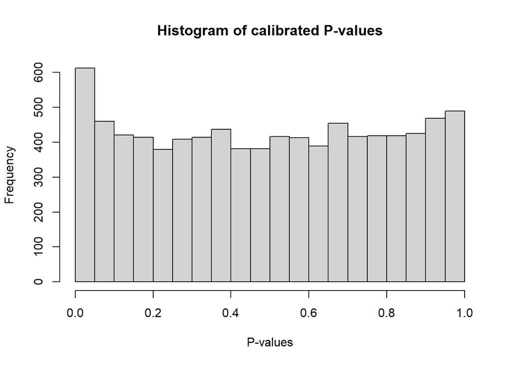

```r
#correcting for GIF
Histogram_of_calibrated_Pvalues_LFMM<-hist(pv_corrected$pvalues,
     main= "Histogram of calibrated P-values",
     xlab= "P-values")
```

```r
#gif values
pv_corrected$gif
```

```
## [1] 2.423337
```

Can we select our-self the GIF values? for LFMM2 univariate method (full= F), yes we can select a GIF values for each climatic variables but for the full model i don’t find how to do it. Arguments to use the univariate vs multivariate models:  
- univariate: less complicated models, less subject to violation of the assumptions, more easy to interpret  
- multivariate: take into account the complex effect or interactions of climatic variables on the genetic variations, reduce the number of test performed?

```
4. Selecting the threshold for candidates
```

We tested the classic threshold of FDR 5% and a more relax one of FDR 10%.

```r
df_pvalues_calibrated <- data.frame(SNP=colnames(genomic_data),pvalues=pv_corrected$pvalues)

#FDR correction
candidates_FDR <- data.frame(snp_names=colnames(genomic_data) ,qvalues=qvalue(pv_corrected$pvalues)$qvalues)

#threshold 0.05
thres_FDR <- 0.05

candidates_T_adapcon_gentree_LFMM_5perc <- data.frame(SNP=candidates_FDR$snp_names[which(candidates_FDR$qvalues<thres_FDR)],qvalues = candidates_FDR$qvalues[which(candidates_FDR$qvalues<thres_FDR)])

length(which(candidates_FDR$qvalues < thres_FDR)) ## how many SNPs we have with an FDR < 5%?
```

```
## [1] 14
```

```r
#FDR 10%
thres_FDR <- 0.1

candidates_T_adapcon_gentree_LFMM_10perc <- data.frame(SNP=candidates_FDR$snp_names[which(candidates_FDR$qvalues<thres_FDR)],qvalues = candidates_FDR$qvalues[which(candidates_FDR$qvalues<thres_FDR)])

length(which(candidates_FDR$qvalues < thres_FDR)) ## how many SNPs we have with an FDR < 10%?
```

```
## [1] 24
```

We plot in a Manhattan plot the candidates with an FDR threshold of 5%

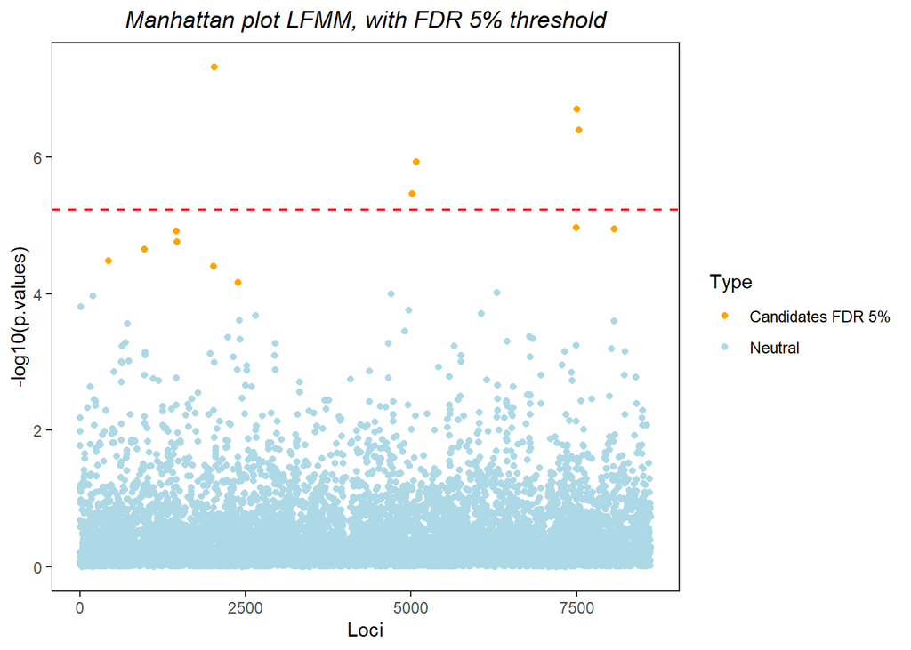

```r
#selection of the candidates from FDR 5%
df_pvalues_calibrated$type <- "Neutral"
df_pvalues_calibrated$type[df_pvalues_calibrated$SNP%in%candidates_T_adapcon_gentree_LFMM_5perc$SNP] <- "Candidates FDR 5%"
df_pvalues_calibrated$type <- as.factor(df_pvalues_calibrated$type)

#Bonferroni threshold
threshold_bonferroni <- 0.05/nrow(df_pvalues_calibrated)

#plot
Manhattan_plot_LFMM_FDR_5perc <- ggplot(df_pvalues_calibrated) +
  geom_point(aes(x=1:nrow(df_pvalues_calibrated), y= -log10(pvalues), col = type), size=1.4) +
  scale_color_manual(values = c("orange","lightblue")) +
  xlab("Loci") + ylab("-log10(p.values)") +
  geom_hline(yintercept= -log10(threshold_bonferroni), linetype="dashed", color = "red", size=0.6) +
  ggtitle("Manhattan plot LFMM, with FDR 5% threshold") +
  guides(color=guide_legend(title="Type")) +
  theme_bw(base_size = 11) +
  theme(legend.position="right", panel.grid = element_blank(), strip.text = element_text(size=11),plot.title = element_text(hjust = 0.5,color = "Black",face="italic"))

plot(Manhattan_plot_LFMM_FDR_5perc)
```

We also plot in a manhattan plot the candidates with an FDR threshold of 5% and 10%

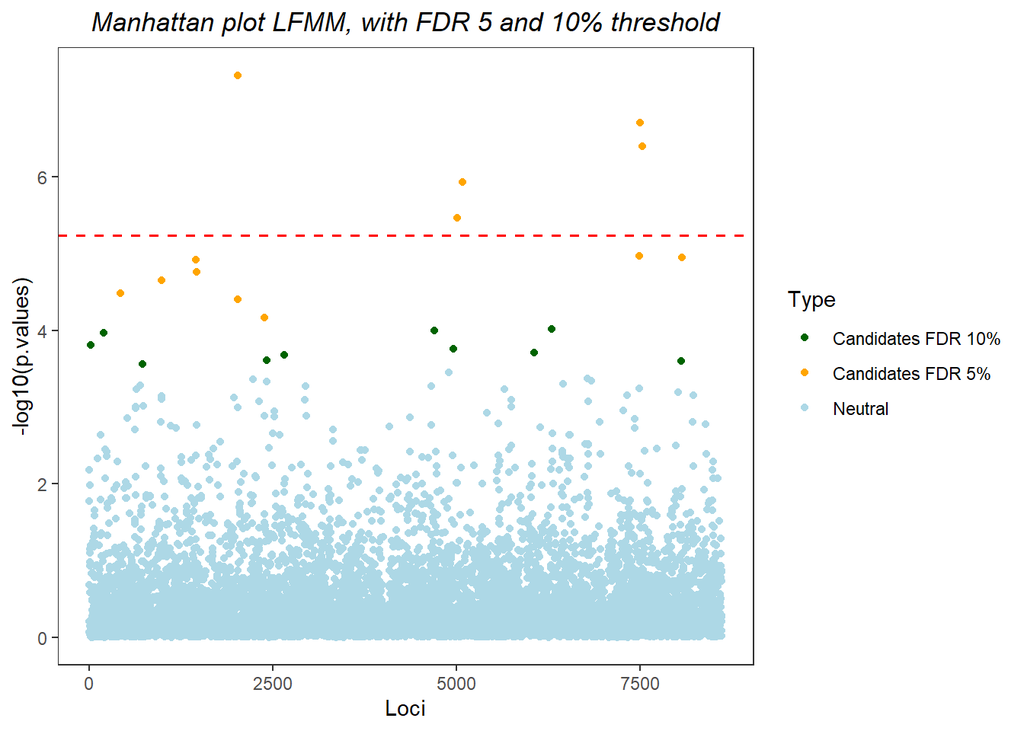

```r
#selection of the candidates from FDR 5 and 10%
df_pvalues_calibrated$type <- "Neutral"
df_pvalues_calibrated$type[df_pvalues_calibrated$SNP%in%candidates_T_adapcon_gentree_LFMM_10perc$SNP] <- "Candidates FDR 10%"
df_pvalues_calibrated$type[df_pvalues_calibrated$SNP%in%candidates_T_adapcon_gentree_LFMM_5perc$SNP] <- "Candidates FDR 5%"
df_pvalues_calibrated$type <- as.factor(df_pvalues_calibrated$type)

#Bonferroni threshold
threshold_bonferroni <- 0.05/nrow(df_pvalues_calibrated)

#plot
Manhattan_plot_LFMM_FDR_5_10perc <- ggplot(df_pvalues_calibrated) +
  geom_point(aes(x=1:nrow(df_pvalues_calibrated), y=-log10(pvalues), col = type), size=1.4) +
  scale_color_manual(values = c("darkgreen","orange","lightblue")) +
  xlab("Loci") + ylab("-log10(p.values)") +
  geom_hline(yintercept=-log10(threshold_bonferroni), linetype="dashed", color = "red", size=0.6) +
  ggtitle("Manhattan plot LFMM, with FDR 5 and 10% threshold") +
  guides(color=guide_legend(title="Type")) +
  theme_bw(base_size = 11) +
  theme(legend.position="right", panel.grid = element_blank(), strip.text = element_text(size=11),plot.title = element_text(hjust = 0.5,color = "Black",face="italic"))

plot(Manhattan_plot_LFMM_FDR_5_10perc)
```

We need to save the candidates identified for downstream analysis

```r
#FDR 5%
write_xlsx(candidates_T_adapcon_gentree_LFMM_5perc,"C:/Users/tfrancisco/Documents/Thèse/Results/species/taxus/GEA_new_var/outliers/candidates_T_adapcon_gentree_LFMM_5perc.xlsx")
save(candidates_T_adapcon_gentree_LFMM_5perc, file="C:/Users/tfrancisco/Documents/Thèse/Results/species/taxus/GEA_new_var/outliers/candidates_T_adapcon_gentree_LFMM_5perc.Rdata")

#FDR 10%
save(candidates_T_adapcon_gentree_LFMM_10perc, file="C:/Users/tfrancisco/Documents/Thèse/Results/species/taxus/GEA_new_var/outliers/candidates_T_adapcon_gentree_LFMM_10perc.Rdata")
```

Corrected matrix for Population structure for GF analysis

We want a matrix of allele frequencies corrected for population structure: Ycorrected = Yfut - UVt = XBt

Below, we do the matrix multiplication of the matrix X (dimension n x b) and the transpose of the matrix B (dimension b x p) to obtain the matrix Ycorrect (dimension n x p) as in Archambeau et al 2024.

The matrix B is the matrix from the lfmm2 output

```r
# matrix X where we x by the matrix B.
Genomic_matrix_corrected_from_LFMM_T_adapcon_gentree <- as.matrix(climatic_data_475[,-c(1:3)]) %*% t(Run_LFMM2@B) %>% set_rownames(row.names(genomic_data)) %>% set_colnames(colnames(genomic_data)) %>% as.data.frame()
```

-> The correct matrix gave very similar values of individuals of the same population because they are closed in the PCA. We have more important differences for individuals far from each other in the PCA (realized by LFMM).

We save the corrected genotypic matrix for GF analysis

```r
#save(Genomic_matrix_corrected_from_LFMM_T_adapcon_gentree, file="C:/Users/tfrancisco/Documents/Thèse/Data/Espèces/Taxus_baccata/genetic_new/GEA_new_var/Genomic_matrix_corrected_from_LFMM_T_adapcon_gentree.Rdata")
```